# Amazon Top 50 Best Selling Books

by Mercy Faith Nyambura Kariuki

# Introduction

Dataset on Amazon's Top 50 bestselling books from 2009 to 2019. Contains 550 books, data has been categorized into fiction and non-fiction using Goodreads

bestsellers with categories.csv data description:

- Name - the name of the book
- Author - the author of the book
- User Rating - user rating of the book
- Reviews - reviews given by users of the books
- Price - price of the book (in dollars)
- Year - year of realease
- Genre - genre of the book

Stages of the project

1. Data Aquisition

2. Data Preprocessing

3. ExploratoryDataAnalysis

4. Research Results

# Stage 1. Data acquisition

> **Let's examine the data provided for the project.**

```python
#import the libraries
import pandas as pd
import numpy as np
import matplotlib.pyplot as plt
import seaborn as sns
import plotly.express as px

import warnings
warnings.filterwarnings("ignore")

%matplotlib inline
```

## Gather the data

```python
books=pd.read_csv("C:/Users/kariu/OneDrive/Desktop/Data Science/Google_Capstone_Project/Choose Your Own Dataset/Amazon Top 50 Best Selling Books/bestsellers with categories.csv")
```

> **Getting the first 5 rows of a table.**

```python
books.head()
```

|  | Name | Author | User Rating | Reviews | Price | Year | Genre |
| --- | --- | --- | --- | --- | --- | --- | --- |
| 0 | 10-Day Green Smoothie Cleanse | JJ Smith | 4.7 | 17350 | 8 | 2016 | Non Fiction |
| 1 | 11/22/63: A Novel | Stephen King | 4.6 | 2052 | 22 | 2011 | Fiction |
| 2 | 12 Rules for Life: An Antidote to Chaos | Jordan B. Peterson | 4.7 | 18979 | 15 | 2018 | Non Fiction |
| 3 | 1984 (Signet Classics) | George Orwell | 4.7 | 21424 | 6 | 2017 | Fiction |
| 4 | 5,000 Awesome Facts (About Everything!) (Natio... | National Geographic Kids | 4.8 | 7665 | 12 | 2019 | Non Fiction |

```python
# getting general information about the data in the sales table
books.info()
```

```
<class 'pandas.core.frame.DataFrame'>
RangeIndex: 550 entries, 0 to 549
Data columns (total 7 columns):
 #   Column       Non-Null Count  Dtype
---  ------       --------------  -----
 0   Name         550 non-null    object
 1   Author       550 non-null    object
 2   User Rating  550 non-null    float64
 3   Reviews      550 non-null    int64
 4   Price        550 non-null    int64
 5   Year         550 non-null    int64
 6   Genre        550 non-null    object
dtypes: float64(1), int64(3), object(3)
memory usage: 30.2+ KB
```

## Data Assessment and Cleaning

> - **We have gathered our data from 1 source. Now let us do data assessment to detect any quality or tidy issues in the data.**

*It is enough to find no quality issues, and no tidy issue. The data has 1 float datatype, 3 integer datatype an 3 object datatype*

# Stage 2. Data preprocessing

> **We will convert the data to the required types, process the gaps (with filling where possible), check the data for duplicates.**

```python
books.duplicated().any()
```

```
False
```

> *There are no duplicated values*

```python
books.isnull().sum()
```

```
Name           0
Author         0
User Rating    0
Reviews        0
Price          0
Year           0
Genre          0
dtype: int64
```

```python
books.shape
```

```
(550, 7)
```

```python
books.nunique()
```

```
Name           351
Author         248
User Rating     14
Reviews        346
Price           40
Year            11
Genre            2
dtype: int64
```

```python
books['User Rating'].unique()
```

```
array([4.7, 4.6, 4.8, 4.4, 4.5, 3.9, 4.3, 4.2, 4.9, 3.8, 3.6, 4. , 4.1,
       3.3])
```

```python
books.Price.unique()
```

```
array([  8,  22,  15,   6,  12,  11,  30,   3,   2,  32,   5,  17,   4,
        13,  14,   9,  24,  21,  18,   0,  28,  16,  10, 105,  20,   1,
         7,  19,  54,  52,  25,  27,  46,  39,  53,  40,  36,  82,  23,
        42], dtype=int64)
```

```python
books.Year.unique()
```

```
array([2016, 2011, 2018, 2017, 2019, 2014, 2010, 2009, 2015, 2013, 2012],
      dtype=int64)
```

```python
books.Genre.unique()
```

```
array(['Non Fiction', 'Fiction'], dtype=object)
```

```python
books.describe()
```

|  | User Rating | Reviews | Price | Year |
| --- | --- | --- | --- | --- |
| count | 550.000000 | 550.000000 | 550.000000 | 550.000000 |
| mean | 4.618364 | 11953.281818 | 13.100000 | 2014.000000 |
| std | 0.226980 | 11731.132017 | 10.842262 | 3.165156 |
| min | 3.300000 | 37.000000 | 0.000000 | 2009.000000 |
| 25% | 4.500000 | 4058.000000 | 7.000000 | 2011.000000 |
| 50% | 4.700000 | 8580.000000 | 11.000000 | 2014.000000 |
| 75% | 4.800000 | 17253.250000 | 16.000000 | 2017.000000 |
| max | 4.900000 | 87841.000000 | 105.000000 | 2019.000000 |

> There are:
> > - 351 book names
> > - 248 authors
> > - 14 different user rating ranging from **3.3 - 4.9**
> > - 346 different reviews
> > - 40 different prices ranging from **0 - 105**
> > - 11 recored years of release ranging from **2009 - 2019**
> > - 2 types of Genres, namely, `Fiction` and `Non-fiction`

> *There are no null values*

# Stage 3. Exploratory data analysis

> **Consider the distribution of books by year of release, evaluate the popularity of genre in certain periods of time, select relevant data for further work, making forecasts and conclusions.**

```python
books.corr()
```

|  | User Rating | Reviews | Price | Year |
| --- | --- | --- | --- | --- |
| User Rating | 1.000000 | -0.001729 | -0.133086 | 0.242383 |
| Reviews | -0.001729 | 1.000000 | -0.109182 | 0.263560 |
| Price | -0.133086 | -0.109182 | 1.000000 | -0.153979 |
| Year | 0.242383 | 0.263560 | -0.153979 | 1.000000 |

> - User Rating has a psitive correletaion to Year of release. .
> - Reviews has a positive correlation to Year of Realease.
> - Price does not seem to any positive correlations with the other features

## -

> - Let's visualize these correlations

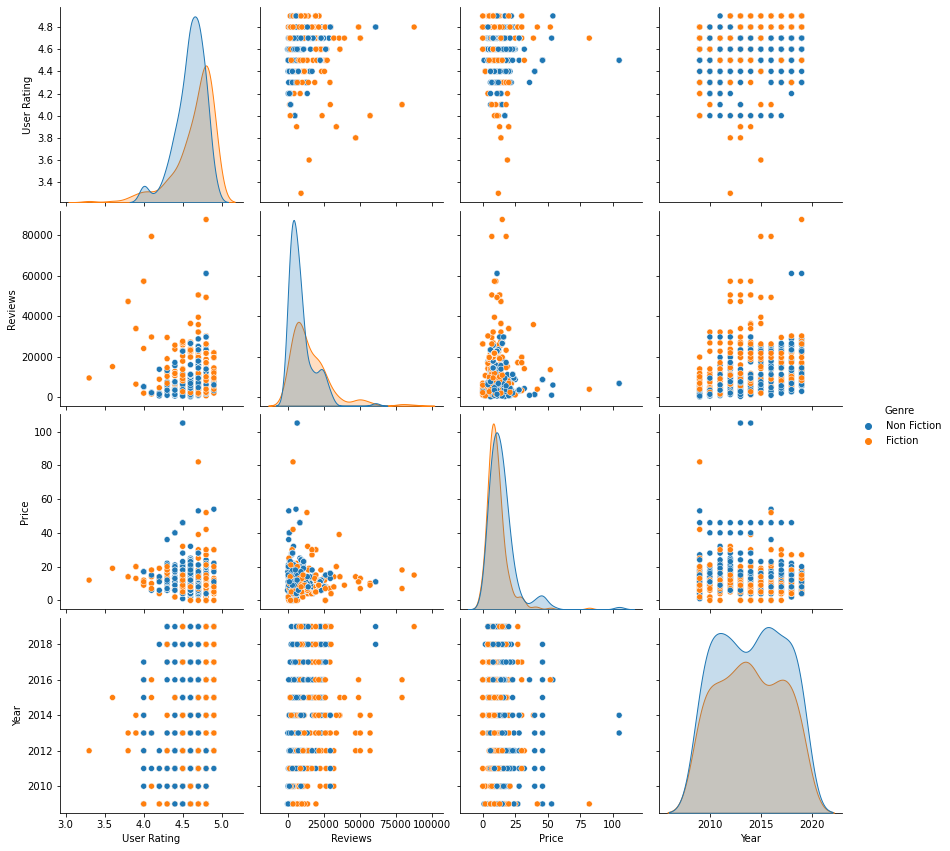

```python
#Plot 1: Below plot shows the pair plots between all features Fiction or Non-Fiction
sns.pairplot(books, hue='Genre', height=3);
```

## Univariate Exploration

### Genre

```python
books.Genre.value_counts()
```

```
Non Fiction    310
Fiction        240
Name: Genre, dtype: int64
```

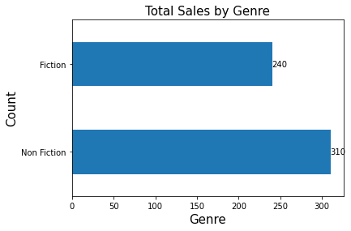

```python
a=books['Genre'].value_counts().plot(kind = 'barh')
a.bar_label(a.containers[0])

#xlabel
plt.xlabel("Genre", fontsize=15);

#ylabel
plt.ylabel("Count", fontsize=15);

#title
plt.title("Total Sales by Genre", fontsize=15);
```

### Year of Release

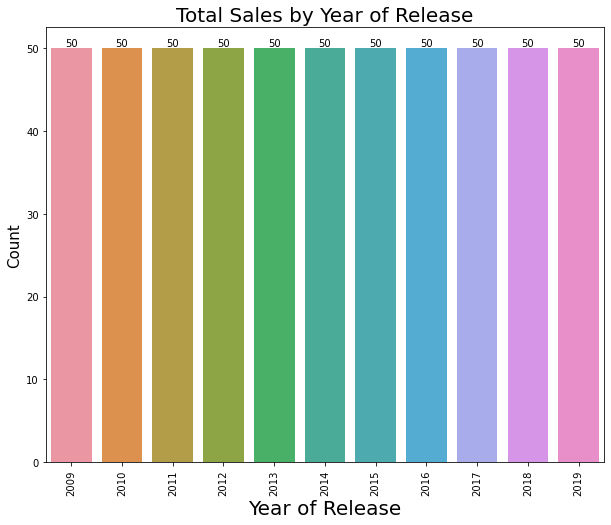

```python
plt.figure(figsize=(10, 8))
a=sns.countplot(x="Year", data=books)
a.bar_label(a.containers[0])
a.tick_params(axis = "x", rotation=90)
plt.xticks(rotation=90);
plt.xlabel("Year of Release", fontsize=20);
plt.ylabel("Count", fontsize=15);
plt.title("Total Sales by Year of Release", fontsize=20);
```

> - **It seems a maxiumum 50 books are released per year between the years 2009 and 2019. The Year of Release has no correleation or causation to the revenues generated from the book sales**

### Price of Books

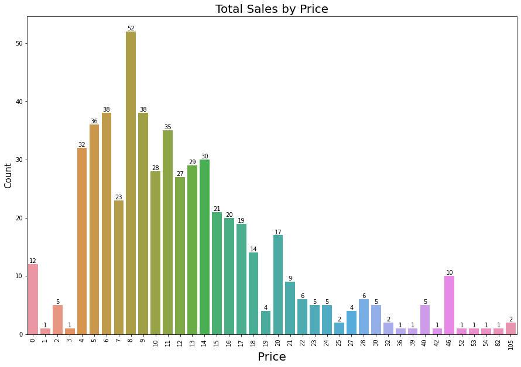

```python
plt.figure(figsize=(15, 10))
a=sns.countplot(x="Price", data=books)
a.bar_label(a.containers[0])
a.tick_params(axis = "x", rotation=90)
plt.xticks(rotation=90);
plt.xlabel("Price", fontsize=20);
plt.ylabel("Count", fontsize=15);
plt.title("Total Sales by Price", fontsize=20);
```

```python
def density_plot(books,col):
    fig=plt.figure(figsize=(12,6))
    sns.kdeplot(books[col],color='blue',shade=True)
    plt.show()
```

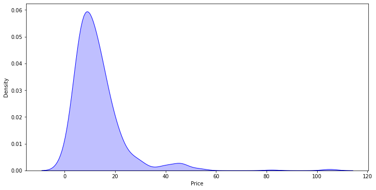

```python
density_plot(books,'Price')
```

### User Rating

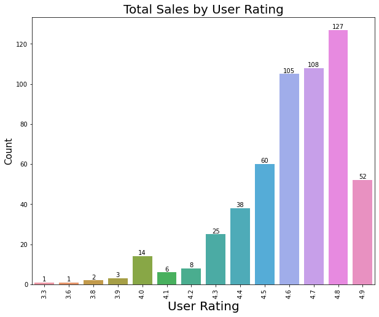

```python
plt.figure(figsize=(10, 8))
a=sns.countplot(x="User Rating", data=books)
a.bar_label(a.containers[0])
a.tick_params(axis = "x", rotation=90)
plt.xticks(rotation=90);
plt.xlabel("User Rating", fontsize=20);
plt.ylabel("Count", fontsize=15);
plt.title("Total Sales by User Rating", fontsize=20);
```

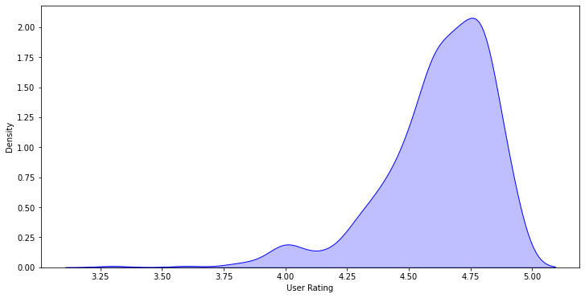

```python
density_plot(books, "User Rating")
```

> > **Majority of the books have a high rating between 4.6 - 4.8 (340 books) which constitutes to 62% of the total books**

### Top Rated Affordable Books

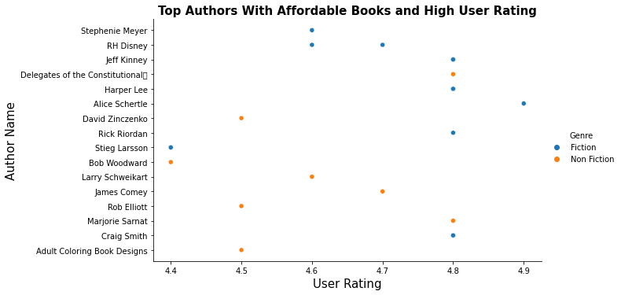

```python
#Plot 3: Below plot shows the top authors whose books costs less with highest user ratings
# plt.figure(figsize=(15,15))
books['count'] = 1
books_affordable = books.loc[books['User Rating'] > 4].sort_values('User Rating', ascending = False).sort_values('Price', ascending = True)
sns.relplot(data = books_affordable[:25], x = 'User Rating',
            y = 'Author',
            hue = 'Genre',
            aspect = 2)

#xlabel
plt.xlabel("User Rating", fontsize=15)

#ylabel
plt.ylabel("Author Name", fontsize=15)

#plot title
plt.title("Top Authors With Affordable Books and High User Rating", fontsize=15, weight="bold")
plt.show()
```

### Recently published affordable books by Genre

> > > **Fiction Lovers**

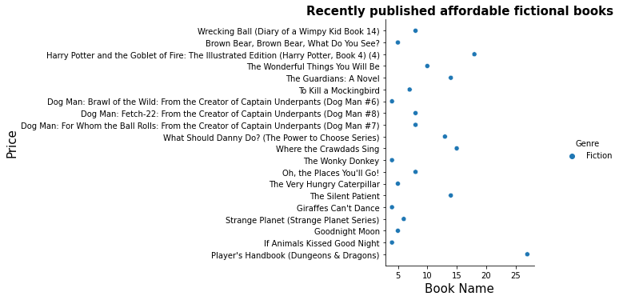

```python
#Plot 4:Below plot shows the top 20 latest and affordable books for fiction lovers
books_affordable = books.loc[books['Genre'] == 'Fiction'].sort_values('Year', ascending = False)
sns.relplot(data = books_affordable[:20], x = 'Price', y = 'Name', hue = 'Genre', aspect = 2);

plt.xlabel("Book Name", fontsize=15)
plt.ylabel("Price", fontsize=15)
plt.title("Recently published affordable fictional books", fontsize=15, weight="bold")
plt.show()
```

> > > **Non-Fictional Lovers**

[output not shown]

[figure not shown]

```python
#Plot 4:Below plot shows the top 20 latest and affordable books for non fiction lovers
plt.figure(figsize=(15,15))
books_affordable = books.loc[books['Genre'] == 'Non Fiction'].sort_values('Year', ascending = False)
sns.relplot(data = books_affordable[:20], x = 'Price', y = 'Name', hue = 'Genre', aspect = 2);

plt.xlabel("Book Name", fontsize=15)
plt.ylabel("Price", fontsize=15)
plt.title("Recently published affordable non-fictional books", fontsize=15, weight="bold")
plt.show()
```

### Top Rate and Reviewed Books

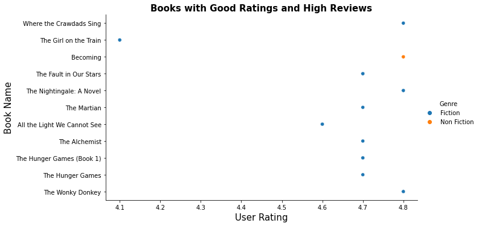

```python
#Plot 5: Below plot shows the books with good ratings and highest reviews
books_affordable = books.loc[books['User Rating'] > 4].sort_values('Price', ascending = True).sort_values('Reviews', ascending = False)
sns.relplot(data = books_affordable[:20], x = 'User Rating', y = 'Name', hue = 'Genre', aspect = 2)

plt.xlabel("User Rating", fontsize=15)
plt.ylabel("Book Name", fontsize=15)
plt.title("Books with Good Ratings and High Reviews", fontsize=15, weight="bold");
```

> > > **It is observed that there's only one non-fiction book (***Becoming*). The other observed outlier is that there one fictional books with a below average rating of 4.1 as compaed to the other fictional book rating.**

## Genre by Year of Release

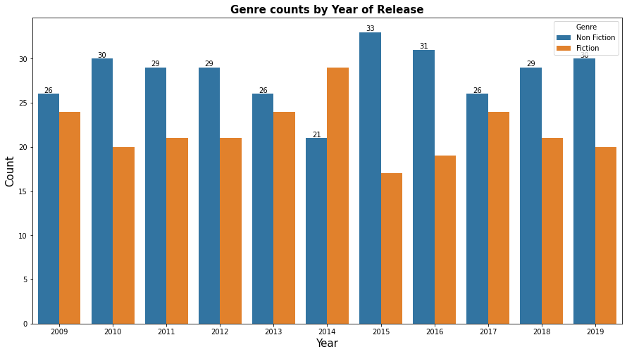

```python
plt.figure(figsize=(15,8))

g=sns.countplot(x = 'Year', data=books, hue ='Genre')
g.bar_label(g.containers[0])
plt.xlabel("Year", fontsize=15)
plt.ylabel("Count", fontsize=15)
plt.title("Genre counts by Year of Release", fontsize=15, weight="bold")
plt.show()
```

> > > **2014 is the only year where Fictional Books were awarded more than the Non Fictional Books**

### Price by User Rating

```python
fig = px.scatter(books, x="User Rating", y="Price", color="Genre")
fig.show()
```

[interactive chart not shown]

> > > **This illustration shows books with high rating are mostly affordable., i.e 0 - 20.**

```python
books.groupby('Author')['Reviews'].sum().sort_values(ascending = False)
```

```
Author
Suzanne Collins      278329
John Green           210419
E L James            178011
Dr. Seuss            176545
Gillian Flynn        171813
                      ...
Larry Schweikart        460
Jon Stewart             440
Edward M. Kennedy       438
Peter A. Lillback       408
Zhi Gang Sha            257
Name: Reviews, Length: 248, dtype: int64
```

```python
reviews_sort_sum = books.groupby('Author')['Reviews'].sum().sort_values(ascending = False)
topfive = reviews_sort_sum[0:5]
topfive_names = reviews_sort_sum[0:5].index
topfive[0]
```

```
278329
```

```python
topfive
```

```
Author
Suzanne Collins    278329
John Green         210419
E L James          178011
Dr. Seuss          176545
Gillian Flynn      171813
Name: Reviews, dtype: int64
```

```python
s = list()

for i in range(5) :
    s.append(topfive_names[i])
    s.append(topfive[i])

print('The most reviewed authors are {0} with {1} reviews, {2} with {3} reviews, {4} with {5} reviews, {6} with {7} reviews and {8} with {9} reviews '.format(*s))
```

```
The most reviewed authors are Suzanne Collins with 278329 reviews, John Green with 210419 reviews, E L James with 178011 reviews, Dr. Seuss with 176545 reviews and Gillian Flynn with 171813 reviews
```

> > > **These are the five more Reviewed Authors.**